# Linear Regression

با استفاده از دیتاست داده شده مدل ماشین لرنینگ بدست آورید که قیمت خانه را با در نظر گرفتن مشخصات آن پیش بینی کند.

data set: USA_Housing.csv.

The data contains the following columns: ستونهای دیتاست به شرح زیر میباشد.

- 'Avg. Area Income': Avg. Income of residents of the city house is located in.درآمد متوسط ساکنان منطقه
- 'Avg. Area House Age': Avg Age of Houses in same city عمرمتوسط خانه ها
- 'Avg. Area Number of Rooms': Avg Number of Rooms for Houses in same city متوسط تعداد اتاقهای هر خانه
- 'Avg. Area Number of Bedrooms': Avg Number of Bedrooms for Houses in same city متوسط تعداد اتاق خوابهای هر خانه
- 'Area Population': Population of city house is located in جمعیت شهر
- 'Price': Price that the house sold at قیمت فروخته شده هر خانه
- 'Address': Address for the house آدرس

**Let's get started!**

### Import Libraries کتابخانه های مورد نیاز را ایمپورت کنید

```python
import pandas as pd
import numpy as np
import matplotlib.pyplot as plt
import seaborn as sns
%matplotlib inline
```

### Check out the Data

Data Understanding

```python
USAhousing = pd.read_csv('USA_Housing.csv')
```

```python
USAhousing.head()
```

|  | Avg. Area Income | Avg. Area House Age | Avg. Area Number of Rooms | Avg. Area Number of Bedrooms | Area Population | Price | Address |
| --- | --- | --- | --- | --- | --- | --- | --- |
| 0 | 79545.45857 | 5.682861 | 7.009188 | 4.09 | 23086.80050 | 1.059034e+06 | 208 Michael Ferry Apt. 674\nLaurabury, NE 3701... |
| 1 | 79248.64245 | 6.002900 | 6.730821 | 3.09 | 40173.07217 | 1.505891e+06 | 188 Johnson Views Suite 079\nLake Kathleen, CA... |
| 2 | 61287.06718 | 5.865890 | 8.512727 | 5.13 | 36882.15940 | 1.058988e+06 | 9127 Elizabeth Stravenue\nDanieltown, WI 06482... |
| 3 | 63345.24005 | 7.188236 | 5.586729 | 3.26 | 34310.24283 | 1.260617e+06 | USS Barnett\nFPO AP 44820 |
| 4 | 59982.19723 | 5.040555 | 7.839388 | 4.23 | 26354.10947 | 6.309435e+05 | USNS Raymond\nFPO AE 09386 |

```python
USAhousing.info()
```

```
<class 'pandas.core.frame.DataFrame'>
RangeIndex: 5000 entries, 0 to 4999
Data columns (total 7 columns):
 #   Column                        Non-Null Count  Dtype
---  ------                        --------------  -----
 0   Avg. Area Income              5000 non-null   float64
 1   Avg. Area House Age           5000 non-null   float64
 2   Avg. Area Number of Rooms     5000 non-null   float64
 3   Avg. Area Number of Bedrooms  5000 non-null   float64
 4   Area Population               5000 non-null   float64
 5   Price                         5000 non-null   float64
 6   Address                       5000 non-null   object
dtypes: float64(6), object(1)
memory usage: 273.6+ KB
```

```python
USAhousing.describe()
```

|  | Avg. Area Income | Avg. Area House Age | Avg. Area Number of Rooms | Avg. Area Number of Bedrooms | Area Population | Price |
| --- | --- | --- | --- | --- | --- | --- |
| count | 5000.000000 | 5000.000000 | 5000.000000 | 5000.000000 | 5000.000000 | 5.000000e+03 |
| mean | 68583.108984 | 5.977222 | 6.987792 | 3.981330 | 36163.516039 | 1.232073e+06 |
| std | 10657.991214 | 0.991456 | 1.005833 | 1.234137 | 9925.650114 | 3.531176e+05 |
| min | 17796.631190 | 2.644304 | 3.236194 | 2.000000 | 172.610686 | 1.593866e+04 |
| 25% | 61480.562390 | 5.322283 | 6.299250 | 3.140000 | 29403.928700 | 9.975771e+05 |
| 50% | 68804.286405 | 5.970429 | 7.002902 | 4.050000 | 36199.406690 | 1.232669e+06 |
| 75% | 75783.338665 | 6.650808 | 7.665871 | 4.490000 | 42861.290770 | 1.471210e+06 |
| max | 107701.748400 | 9.519088 | 10.759588 | 6.500000 | 69621.713380 | 2.469066e+06 |

```python
USAhousing.columns
```

```
Index(['Avg. Area Income', 'Avg. Area House Age', 'Avg. Area Number of Rooms',
       'Avg. Area Number of Bedrooms', 'Area Population', 'Price', 'Address'],
      dtype='object')
```

#### Check for missing values

```python
np.sum(USAhousing.isnull())
```

```
Avg. Area Income                0
Avg. Area House Age             0
Avg. Area Number of Rooms       0
Avg. Area Number of Bedrooms    0
Area Population                 0
Price                           0
Address                         0
dtype: int64
```

```python
#Check if there is duplicate rows
np.sum(USAhousing.duplicated())
```

```
0
```

# EDA (Exploratory Data Analysis)

با این کار دیتاست را بررسی میکنیم تا ببینیم چه اطلاعاتی میتوانیم بدست آوریم

Let's create some simple plots to check out the data!

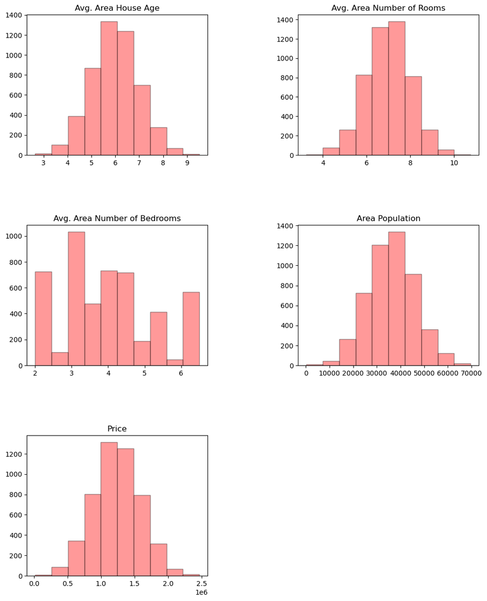

```python
#Histogram of numeric variables
var_ind = list(range(1, 6))
plt.figure(figsize = (12, 15))
plt.subplots_adjust(hspace = 0.5, wspace = 0.5)
for i in range(1, 6):
    plt.subplot(3, 2, i)
    plt.hist(x = USAhousing.iloc[: , var_ind[i - 1]], alpha = 0.4, color = 'red',edgecolor = "black")
    plt.title(USAhousing.columns[var_ind[i - 1]])
```

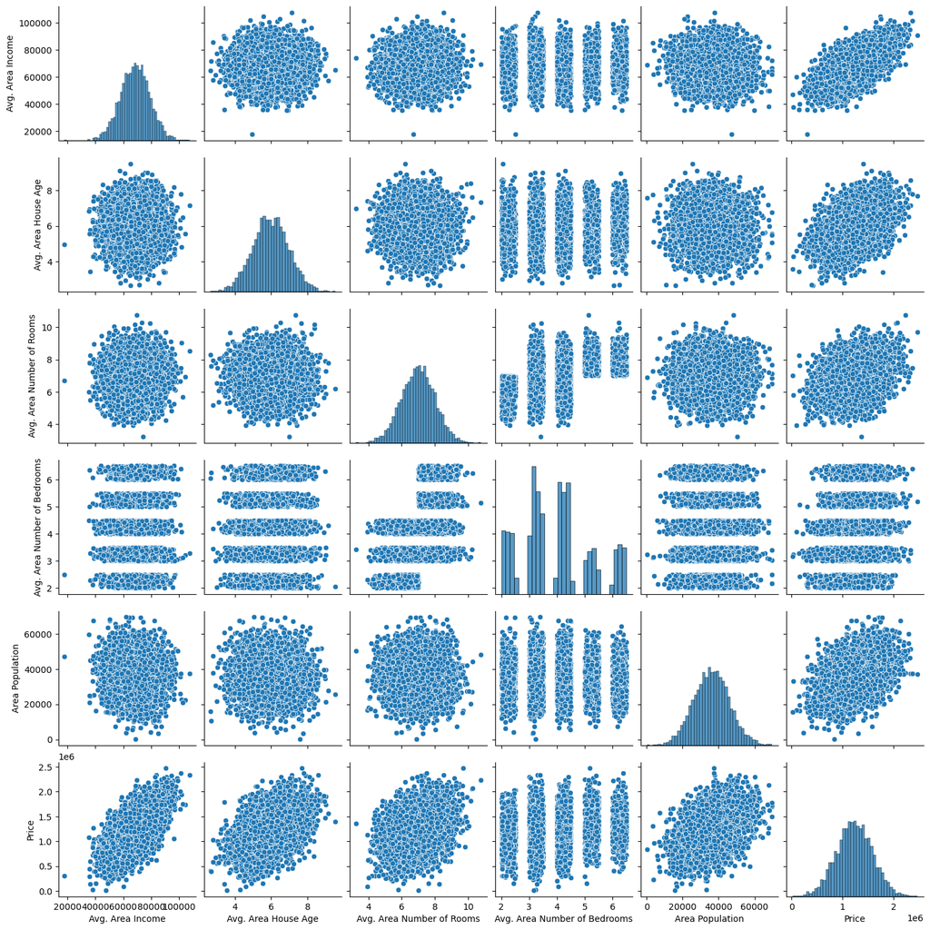

```python
sns.pairplot(USAhousing)
```

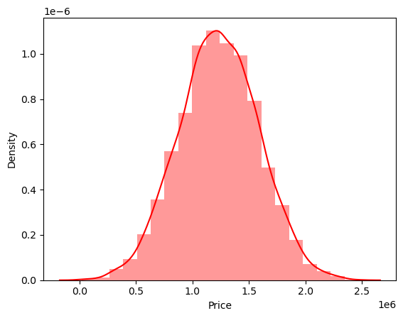

```python
sns.distplot(USAhousing['Price'],bins=20,kde=True,color='red')
```

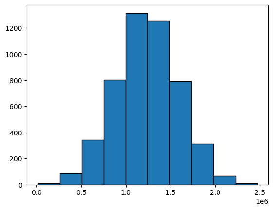

```python
plt.hist(USAhousing['Price'],bins=10,edgecolor = "black")
```

```python
USAhousing['Price'].mean()
```

```
1232072.6541453
```

```python
USAhousing['Price'].std()
```

```
353117.6265810608
```

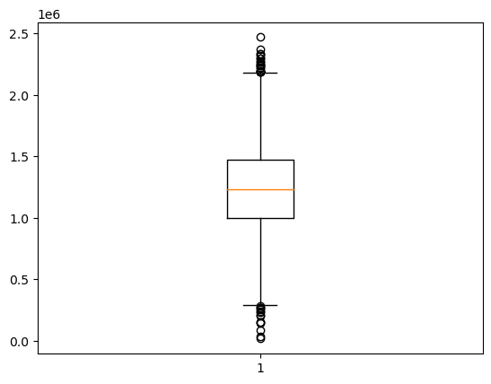

```python
#Check for outliers
plt.boxplot(USAhousing['Price'])
plt.show()
```

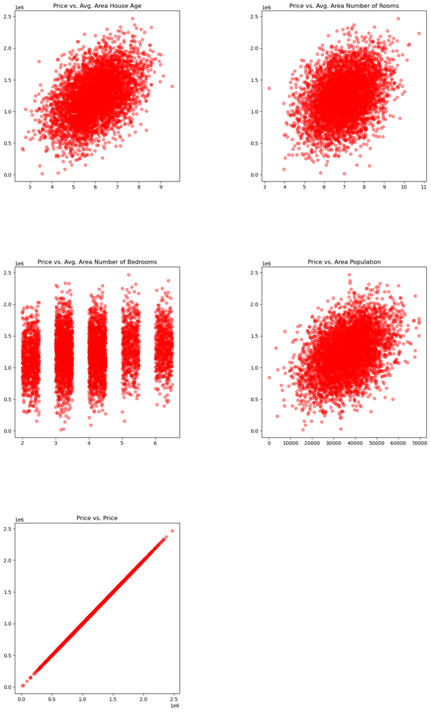

```python
#Scatter plot
var_ind = list(range(1, 6))
plt.figure(figsize = (15, 25))
plt.subplots_adjust(hspace = 0.5, wspace = 0.5)
for i in range(1, 6):
    plt.subplot(3, 2, i)
    plt.scatter(x = USAhousing.iloc[: , var_ind[i - 1]], y = USAhousing['Price'], alpha = 0.4, color = 'red')
    plt.title('Price vs. ' + USAhousing.columns[var_ind[i - 1]])
```